# DATA1001 Group 7 Project

Author

Brace Liu: 540070866, Charlie Wilson: 540717178, Dan Samad: 5206245132, Ellery Prescott: 540697870, Sihan Fang: 540054969, Tuan Minh Le: 540847349

# Recommendation/Insight

# Evidence

## IDA

```r
library(tidyverse)
library(kableExtra)

survey_data <- read.csv("data1001_survey_data.csv")

# Select desired variables
survey_data <- survey_data %>%
  select(friends_count, si_1, data_interest._1)

# Remove rows with missing data in any of the selected columns
survey_data <- survey_data %>%
  filter(!is.na(friends_count) & !is.na(si_1) & !is.na(data_interest._1))

# Data frame after cleaning
survey_data %>%
  kbl() %>%
  column_spec(3, width = "4cm") %>%
  kable_styling(bootstrap_options = c("striped", "hover", "condensed", "responsive"), position = "center") %>%
  kable_minimal(full_width = F) %>%
  scroll_box(width = "100%", height = "400px")
```

| friends_count | si_1 | data_interest._1 |
| --- | --- | --- |
| 5 | 7 | 3 |
| 15 | 2 | 7 |
| 2 | 5 | 4 |
| 0 | 0 | 0 |
| 6 | 3 | 7 |
| 3 | 6 | 7 |
| 15 | 7 | 5 |
| 5 | 5 | 7 |
| 5 | 0 | 2 |
| 0 | 5 | 5 |
| 15 | 2 | 4 |
| 1 | 1 | 10 |
| 45 | 3 | 6 |
| 0 | 9 | 6 |
| 10 | 5 | 5 |
| 15 | 6 | 8 |
| 30 | 3 | 2 |
| 5 | 4 | 0 |
| 10 | 4 | 2 |
| 25 | 7 | 5 |
| 6 | 8 | 5 |
| 6 | 3 | 4 |
| 3 | 5 | 8 |
| 5 | 6 | 6 |
| 10 | 6 | 6 |
| 10 | 4 | 10 |
| 15 | 3 | 6 |
| 20 | 10 | 3 |
| 5 | 7 | 7 |
| 5 | 3 | 5 |

[output cut: 494 more lines]

The data was derived from a voluntary, anonymous questionnaire. The questionnaire adopts the method of randomising question blocks to ensure the comprehensiveness and validity of data. The purpose was to examine the behaviours of students in data science classes at the University of Sydney. The dataset contains 533 rows and 30 columns, giving the dataset a dimension of 30. The relevant variables include “Interest in Data Science” (quantitative discrete), “Stress Level” (quantitative discrete) and “Friends Count at USYD” (quantitative discrete). Limitations in the dataset include self-selection bias and confounding variables impacting the validity of the study. Being a voluntary survey, only those students who give their consent are going to form part of the study, potentially allowing for systematic errors as a result of self-selection bias. For example those who are willing to partake in the study are likely more studious and may have a higher interest in the subject. It can be hypothesised that stress level may rise as interest in data science decreases, and linearity may be assumed between Friend count and stress allowing for use of the regression model. As for extreme error values social desirability bias can be assumed, where one may have had a fluctuating mood or may have altered their response due to their social surroundings. From the datasets’ 30 variables, our research only focuses on 3 variables: friends count, stress level and data interest. We may clean it by isolating those variables, removing the rest. However, there is some missing data somewhere in each column, so we first must identify these values and remove them.

## Does stress level affect participants’ interest level in data science ?

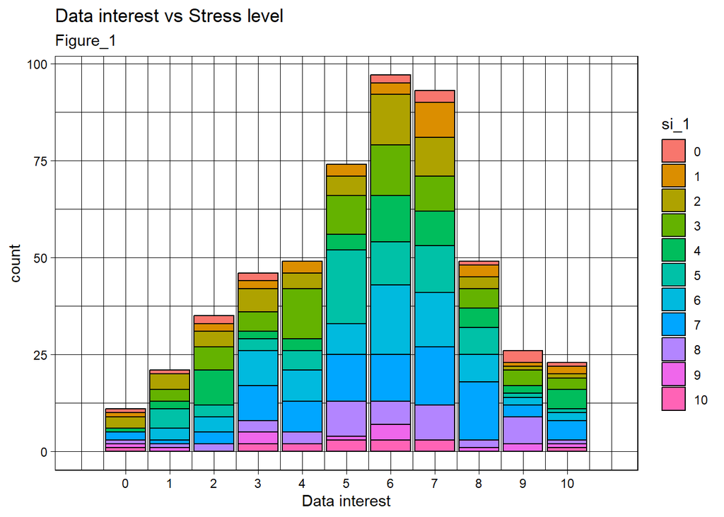

```r
library(tidyverse)

survey_data <- read.csv("data1001_survey_data.csv")

survey_data <- survey_data %>%
  select(friends_count, si_1, data_interest._1)

survey_data <- survey_data %>%
  filter(!is.na(friends_count) & !is.na(si_1) & !is.na(data_interest._1))

survey_data$si_1 = as.factor(survey_data$si_1)
ggplot(survey_data, aes(x=data_interest._1)) +
  geom_bar(aes(fill=si_1),
           color = "black"
           ) +
  labs(x="Data interest",
       title="Data interest vs Stress level",
       subtitle = "Figure_1"
      ) +
  scale_x_continuous(
    limits = c(-1, 11),
    breaks = seq(0, 10, 1)
  ) +
  theme_linedraw() +
  theme(legend.position = "right")
```

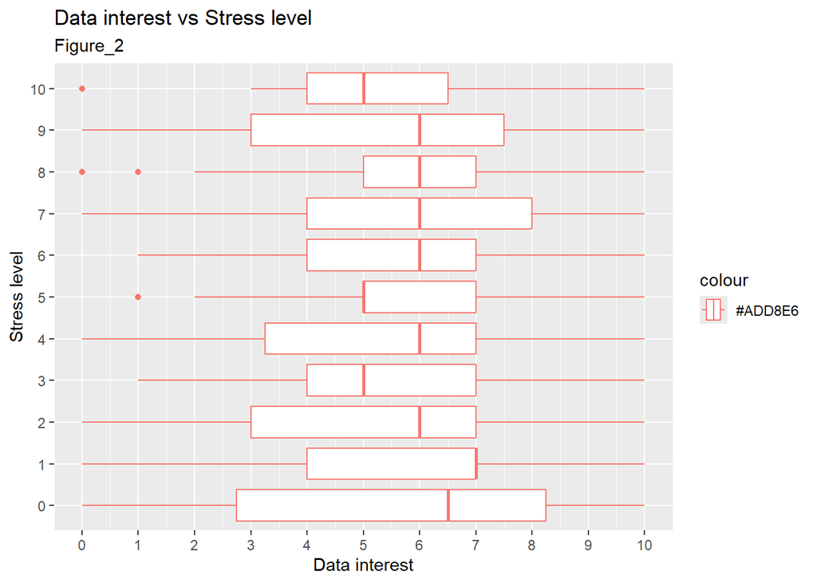

```r
ggplot(survey_data, aes(x = data_interest._1, y = si_1)) +
  geom_boxplot(aes(color = "#ADD8E6")) +
  labs(
    x = "Data interest",
    y = "Stress level",
    title = "Data interest vs Stress level",
    subtitle = "Figure_2"
  )  +
  scale_x_continuous(
    limits = c(0, 10),
    breaks = seq(0, 10, 1)
  )
```

## Is having more friends associated with lower stress ?

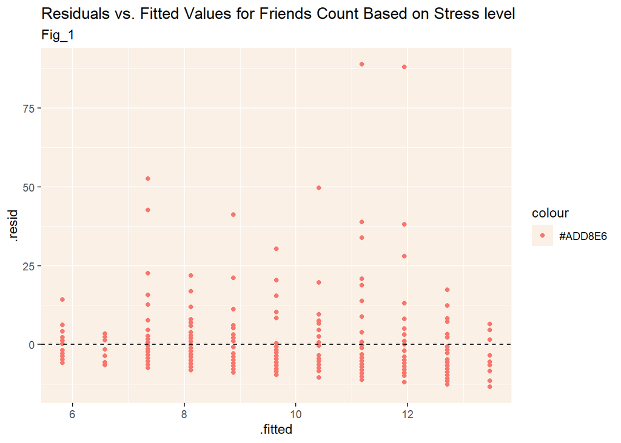

```r
library(tidyverse)

survey_data <- read.csv("data1001_survey_data.csv")

survey_data <- survey_data %>%
  select(friends_count, si_1, data_interest._1)

survey_data <- survey_data %>%
  filter(!is.na(friends_count) & !is.na(si_1) & !is.na(data_interest._1))

model = lm(friends_count ~ si_1, data = survey_data)

ggplot(model, aes(x= .fitted, y= .resid, color = "#ADD8E6")) +
  geom_point() +
  geom_hline(yintercept = 0,
             linetype = "dashed",
             colour = "black") +
  labs(title = "Residuals vs. Fitted Values for Friends Count Based on Stress level", subtitle="Fig_1") +
  theme(panel.background = element_rect(fill = "linen"))
```

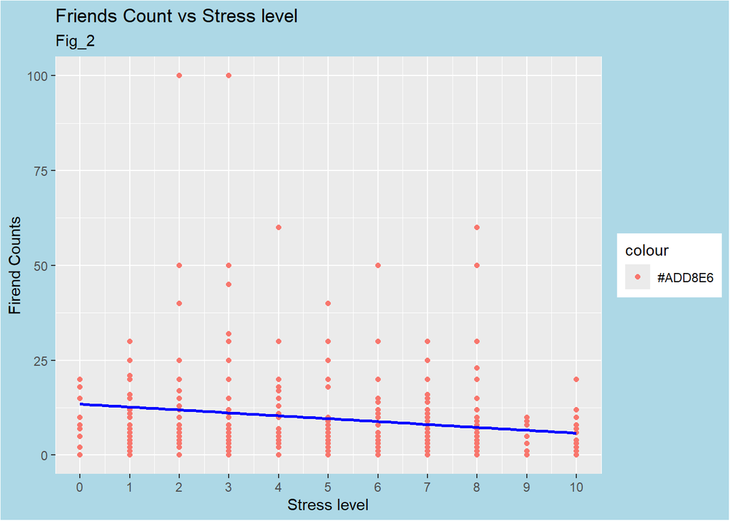

```r
ggplot(survey_data, aes(x=si_1, y=friends_count, color = "#ADD8E6")) + # Specify x and y variables
  geom_point() + # Create scatter plot
  geom_smooth(method="lm", se=FALSE, color = "blue") + # Add line of best fit
  labs(x="Stress level", y="Firend Counts", title="Friends Count vs Stress level", subtitle="Fig_2")+
  scale_x_continuous(limits = c(0, 10), breaks = seq(0, 10, 1)) +
  theme(plot.background = element_rect(fill = "lightblue"))
```

## Articles

(No date a) *The role of friendships in first-year students’ university …* Available at: https://unistars.org/papers/STARS2017/08A.pdf (Accessed: 13 September 2024).

Alotaibi, T.A. *et al.* (2023) *The benefits of friendships in academic settings: A systematic review and meta-analysis*, *Cureus*. Available at: https://www.ncbi.nlm.nih.gov/pmc/articles/PMC10800095/#:~:text=Friendships%20foster%20a%20supportive%20environment,to%20a%20successful%20academic%20experience. (Accessed: 13 September 2024).

# Acknowledgements

## Group meetings

In preparation for this project, we held an offline meeting at 5:00 pm on September 9th in the Scitch Library, with a total of 4 people present. During the meeting, we improved and completed the relevant statistical charts in R Studio.

## Contribution

Charlie Wilson was responsible for data structure in the Initial Data Analysis part. Tuan Minh Le was responsible for data cleaning in the Initial Data Analysis part. Dan Samad and Ellery Prtscott were responsible for data limitations in the Initial Data Analysis part. Brace Liu was responsible for data source in the Initial Data Analysis part. Sihan Fang was responsible for data assumptions in the Initial Data Analysis part.

In the next work, Brace Liu and Sihan Fang are mainly responsible for slides design and acknowledgements. Charlie Wilson is mainly responsible for writing two paragraphs that delve into our researches questions as well as a brief explanation showing how one Shared Value and one Ethical Principle have been followed by a professional standard of report. Tuan Minh Le is mainly responsible for coding and assembling resources into a Quarto document.

## Resources used

- We used chat gpt to create a picture for the slide

Screenshot of how the imaged was created by ChatGPT:

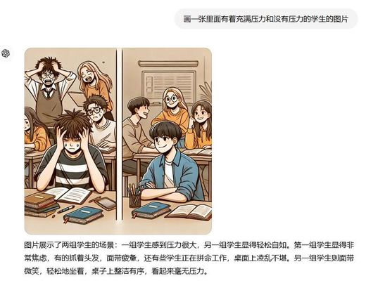

- We find some information on ED Discussion:

Su, J. (2024) about acknowledgements part of the project report, Ed discussion. Available at: https://edstem.org/au/courses/16787/discussion/2217101 (Accessed: 13 September 2024).

Ui, Y. (2024) Report formatting, Ed discussion. Available at: https://edstem.org/au/courses/16787/discussion/2219281 (Accessed: 13 September 2024).

Zhai, S. (2024) Project problem, Ed discussion. Available at: https://edstem.org/au/courses/16787/discussion/2213052 (Accessed: 13 September 2024).

Xu, M. (2024) IDA, Ed discussion. Available at: https://edstem.org/au/courses/16787/discussion/2210192 (Accessed: 13 September 2024).

- We referred to the following articles to help us with our analysis:

(No date a) *The role of friendships in first-year students’ university …* Available at: https://unistars.org/papers/STARS2017/08A.pdf (Accessed: 13 September 2024).

Alotaibi, T.A. *et al.* (2023) *The benefits of friendships in academic settings: A systematic review and meta-analysis*, *Cureus*. Available at: https://www.ncbi.nlm.nih.gov/pmc/articles/PMC10800095/#:~:text=Friendships%20foster%20a%20supportive%20environment,to%20a%20successful%20academic%20experience. (Accessed: 13 September 2024).

- We referred to the following resources to help us with our coding:

(No date) YouTube. Available at: https://youtu.be/sV5lwAJ7vnQ?s i=GqSMRSThJAvhJIiN (Accessed: 13 September 2024).

(No date) YouTube. Available at: https://youtu.be/3iz-2iM4RFE?s i=e6rOXGGhCZZZsoQU (Accessed: 13 September 2024).

### How one Shared Value and one Ethical Principle have been followed by a professional standard of report

Shared Professional Values: Whilst researching our chosen questions, our group maintained an objective statistical approach through our IDA, in order to provide an accurate and trustworthy recommendation to our client.

Ethical Principles: Throughout the completion of our project our group ensured clear clarification of obligations and roles, equally allocating different aspects of the project whilst also working together and helping one another. This was structured through group meetings and in class discussions.